# R Notebook

```r
library(tidyverse)
```

```r
library(smmr)
```

## Introduction

The Mayo Clinic states that dandruff is a a common condition that causes the skin on the scalp to flake. In other words it is an excessive amount of dry dead skin cells on the scalp. For many people this can be an embrassing condition despite not being medically serious. The itching and flaking of dandruff can be controlled by using a different type of shampoo aimed to reduce the amount of flaking in the scalp. Which shampoo is the best to provide to patients is the question. A study looked at four different shampoos and tested them to see if it had a difference on the amount of flakes. The first shampoo is PyrI which has 1% pyrithione zinc in it. The second shampoos is PyrII which is the same as PyrI but you are asked to shampoo twice at each wash. The third shampoo is Keto which has 2% ketoconazole in it. The final shampoo is a placebo shampoo to see if flaking can be affected by mental awareness’ of the condition.

## Method

Participants were randomly assigned to four different shampoos; pyrI, pyrII, Keto and a placebo shampoo. Eight sections of the scalp were examined for each participant after six weeks of treatment and each of the eight sections were fiven a score that measured the amount of flaking on a scale of 0-10. A variable “Flaking” was obtained by getting the sum of these eight scores.

We obtain the data collected and read it into a table so that it is easier to analyze the data.

```r
my_url <- "http://ritsokiguess.site/STAC32/dandruff.txt"
dandruff <- read.table(my_url, header = TRUE)
dandruff
```

[output not shown]

## Graph

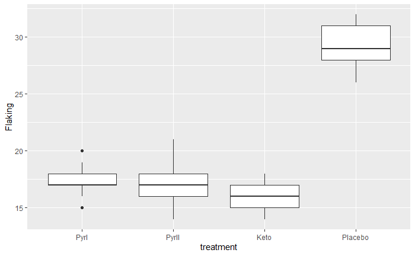

```r
dandruff %>%
  mutate(treatment=fct_inorder(Treatment)) %>%
  ggplot(aes(x=treatment, y=Flaking)) + geom_boxplot()
```

## Analysis of Graph Data

We want to make sure the difference that is observed from the graph is accurate. Since, the samples are not normal enough due to outliers, we will run a Mood Median Test across the four groups.

We obtain the median of all flaking regardless of shampoos and count how many observations in each treatment are above/below the overall median.

```r
(dandruff %>% summarize(med = median(Flaking)) %>% pull(med) -> m)
```

```
[1] 17
```

```r
tab = with(dandruff, table(Treatment, Flaking > m))
tab
```

```
Treatment FALSE TRUE
  Keto      100    6
  Placebo     0   28
  PyrI       62   50
  PyrII      65   44
```

THe Mood’s median test shows that our overall median is 17, therefore we must see which treatment is above or below this median of 17. The test shows that the Placeboo shampoo is well above the overall median while the Keto is well below the overall median. Our test further shows that PyrI and PyrII have about a 50/50 distribution of above and below suggested not much difference as stated earlier when observing the boxplot graph.

Although, we can observe the differences according to which one is above or below the overall median. It would be better if we get separately compare each treatment individually to one another to test significant differences. We use a pairwise median test to see each treatment versus another treatment. Keto and Placebo are paired, keto and pyrI are paired, keto and pyrII are paired, placebo and pyrI are paired, placebo and pyrII are paired and finally pyrI and pyrII are paired.

```r
pairwise_median_test(dandruff,Flaking,Treatment)
```

| g1 | g2 | p_value | adj_p_value |
| --- | --- | --- | --- |
| Keto | Placebo | 5.172203e-06 | 3.103322e-05 |
| Keto | PyrI | 4.596411e-16 | 2.757847e-15 |
| Keto | PyrII | 8.112028e-08 | 4.867217e-07 |
| Placebo | PyrI | 4.884320e-13 | 2.930592e-12 |
| Placebo | PyrII | 2.269611e-12 | 1.361767e-11 |
| PyrI | PyrII | 3.057536e-02 | 1.834522e-01 |

## Conclusion

Overall, when deciding which shampoo to use its clearly evident that using the placebo shampoo will produce the worst result and give more or no difference to pre-existing flaking. This indicates that there are no placeboo effects or mental reasons that may affect flaking. The best shampoo to use out of the four is the keto shampoo as it as the lowest amount of flaking and shows significant differences amongst the other treatments. If you want to decide between the pyrI and pyrII shampoo; there is no difference in the results it produces for flaking despite the fact that pyrII suggests using it twice in one wash. The 2% ketoconazole shampoo is the best option when you have dandruff and want to reduce the amount of flakes you have on your scalp.